# Normal Temperature Estimation

July 20, 2018

## The app

The Normal Temperature Estimation is a web based application that helps people estimate their body temperature based on their heart rate and gender, using a machine learning algorithm.

The Normal Temperature Estimation can be found on the following link:

http://kggen.shinyapps.io/norm-temp-app

Documentation for the project can be found on this [link](http://github.com/kggen/norm-temp-app)

## Architecture of the app

The Normal Temperature Estimation app uses the shinyapps.io infrastructure, wich hosts the ui.R and server.R files.

Technologies used include:

- R
- RStudio
- shinyapps.io

## The model

The underlying machine learning model is *linear regression* that calculates your body temperature instantly when selecting the options in the app, i.e. heart rate and gender.

The data used for training the model is the normtemp database from the UsingR library, which was contributed by Allen L. Shoemaker to the Journal of Statistics Education. More information about the dataset can be found on the follwing [link](http://www.amstat.org/publications/jse/datasets/normtemp.txt).

The training dataset uses 130 measurements of body temperature and builds the model by regressing them against gender and heart rate.

## The normtemp dataset

Here's a plot of the training dataset:

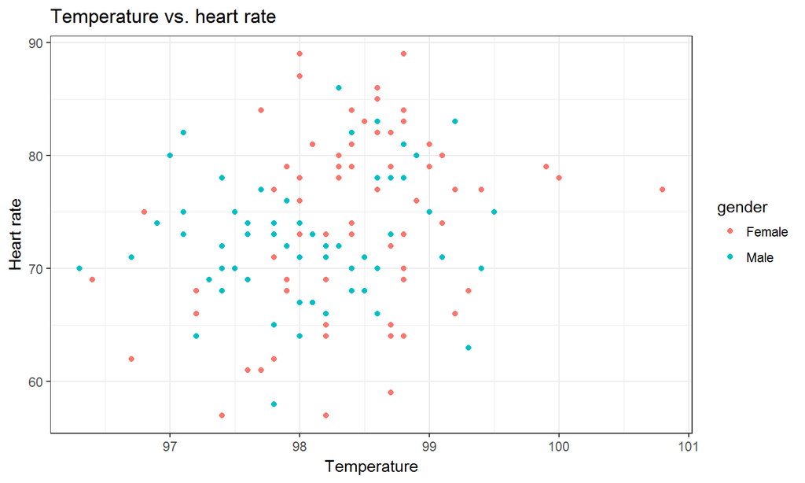